# Part 1 Introduction

## 1.1 Motivation

Over the past 15 years, social media has become an important communication tool for politicians. One of the pioneers of this novel approach has been Donald Trump, the 45th and 47th President of the United States. His prominent level of posting is clearly visible on Figure 1.1, where the gap between 2021 and 2022 represents his ban from Twitter after the January 6th riots.[^1]

The content of his posts can sometimes have announcements or teases of future political decisions. Note the recent infamous “THIS IS A GREAT TIME TO BUY!!! DJT” post sent just an hour before lifting his reciprocal tariffs. It is then not improbable that agents in financial markets might take this information into account in their decision making. This question has been asked before in the literature, primarily focusing on his first term.

This brings us to our research question: Do Donald Trump’s posts impact market volatility?

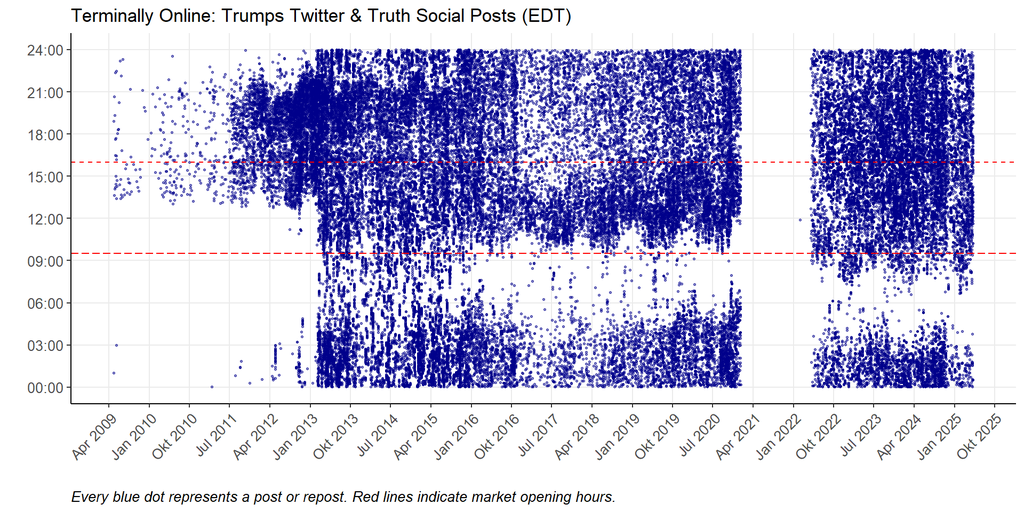

Figure 1.1: Terminally Online: Trump’s Twitter & Truth Social Posts (EDT)

## 1.2 Literature Review

Information is one of the most valuable assets in the financial market. Its importance lies at the core of the **Efficient Market Hypothesis**, which states that the prices of assets fully reflect all available information, adjusting immediately to any new data (Fama et al. (2003)), and thereby creating a strong demand for information flow. In addition, the **Mixture of Distribution Hypothesis** states that the release of new information is closely linked to movements in both realized and implied volatility (Andersen (1996), French & Roll (1986), Vlastakis & Markellos (2012)).

Consequently, a large part of the literature has focused on the relationship between announcements, news and market activity. For example, Schumaker & Chen (2009) use various linguistic and textual representations derived from financial news to predict stock market prices. Similarly, Ederington & Lee (1993) analyze the impact of macroeconomic news announcements on interest rate and foreign exchange futures markets, particularly in terms of price changes and volatility. Both studies, among others, find that prices, such as stock prices, react primarily *within minutes* after the release of new information.

Recently, the world has witnessed the rise of the Internet which revolutionized the dissemination and accessibility of information. Social media enables investors, analysts or politicians to instantly share their information, news or opinions. This led some studies to focus on the communication dynamics of social platforms to predict changes in the returns of financial assets (De Choudhury et al. (2008) and Bartov et al. (2018)). In this context, the impact of Trump’s tweets on various financial and macroeconomic variables has been analysed by several studies, especially during his first mandate. Using high-frequency financial data, Gjerstad et al. (2021) found *consistent increases* in uncertainty and trading volume, along with a decline in the US stock market, regardless of tweet content. It is relevant to note however, that the effect was stronger when Trump used confrontational words such as “tariff” or “trade war.” Some of his announcements also influenced the U.S. dollar exchange rate (Vlastakis & Markellos (2012)) and certain market indices within minutes of the tweet being posted (Colonescu (2018) and Kinyua et al. (2021)).

Furthermore, scholars have shown that negative Trump tweets about specific companies tended to reduce demand for their stocks (Brans & Scholtens (2020) and Mendels (2019)), whereas some others have shown that they also impact market volatility indices such as the VIX (Fendel et al. (2019)) or the Volfele (Klaus & Koser (2021)). The effects of his tweets also extended beyond the US. For example, Nishimura & Sun (2025) show a positive relationship between volatility in European stock markets and Twitter activity of Trump, and this effect tends to intensify as public interest for his tweet grows.

Our paper is built as follows: Section 2 describes the data, their sources, and the several transformations applied. Section 3 focuses on ARMA-X models, describing both our methodology and results. Section 4 does the same, though for our VAR models. Section 5 concludes and importantly Section 7 provides all the figures and tables.

### References

Andersen, T. G. (1996). Return Volatility and Trading Volume: An Information Flow Interpretation of Stochastic Volatility. *The Journal of Finance*, *51*(1), 169–204. https://doi.org/10.2307/2329306

Bartov, E., Faurel, L., & Mohanram, P. S. (2018). Can Twitter Help Predict Firm-Level Earnings and Stock Returns? *The Accounting Review*, *93*(3), 25–57. https://doi.org/10.2308/accr-51865

Brans, H., & Scholtens, B. (2020). Under his thumb the effect of president Donald Trump’s Twitter messages on the US stock market. *PLOS ONE*, *15*(3), e0229931. https://doi.org/10.1371/journal.pone.0229931

Colonescu, C. (2018). The Effects of Donald Trump’s Tweets on US Financial and Foreign Exchange Markets. *Athens Journal of Business & Economics*, *4*(4), 375–388.

De Choudhury, M., Sundaram, H., John, A., & Seligmann, D. D. (2008). Can blog communication dynamics be correlated with stock market activity? *Proceedings of the Nineteenth ACM Conference on Hypertext and Hypermedia*, 55–60. https://doi.org/10.1145/1379092.1379106

Ederington, L. H., & Lee, J. H. (1993). How Markets Process Information: News Releases and Volatility. *The Journal of Finance*, *48*(4), 1161–1191. https://doi.org/10.2307/2329034

Fama, E. F., Fisher, L., Jensen, M. C., & Roll, R. W. (2003). The Adjustment of Stock Prices to New Information. *SSRN Electronic Journal*. https://doi.org/10.2139/ssrn.321524

Fendel, R., Burggraf, T., & Huynh, T. L. D. (2019). *Political News and Stock Prices: Evidence from Trump’s Trade War* ({{SSRN Scholarly Paper}} No. 3479822). Social Science Research Network.

French, K. R., & Roll, R. (1986). Stock return variances: The arrival of information and the reaction of traders. *Journal of Financial Economics*, *17*(1), 5–26. https://doi.org/10.1016/0304-405X(86)90004-8

Gjerstad, P., Meyn, P. F., Molnár, P., & Næss, T. D. (2021). Do President Trump’s tweets affect financial markets? *Decision Support Systems*, *147*, 113577. https://doi.org/10.1016/j.dss.2021.113577

Kinyua, J. D., Mutigwe, C., Cushing, D. J., & Poggi, M. (2021). An analysis of the impact of President Trump’s tweets on the DJIA and S&P 500 using machine learning and sentiment analysis. *Journal of Behavioral and Experimental Finance*, *29*, 100447. https://doi.org/10.1016/j.jbef.2020.100447

Klaus, J., & Koser, C. (2021). Measuring Trump: The Volfefe Index and its impact on European financial markets. *Finance Research Letters*, *38*(C).

Mendels, G. (2019). Stanford Research Series: Making Trading Great Again: Trump-based Stock Predictions via Doc2vec…. In *Comet*.

Nishimura, Y., & Sun, B. (2025). Impacts of Donald Trump’s tweets on volatilities in the European stock markets. *Finance Research Letters*, *72*, 106491. https://doi.org/10.1016/j.frl.2024.106491

Schumaker, R. P., & Chen, H. (2009). Textual analysis of stock market prediction using breaking financial news: The AZFin text system. *ACM Trans. Inf. Syst.*, *27*(2), 12:1–12:19. https://doi.org/10.1145/1462198.1462204

Vlastakis, N., & Markellos, R. N. (2012). Information demand and stock market volatility. *Journal of Banking & Finance*, *36*(6), 1808–1821. https://doi.org/10.1016/j.jbankfin.2012.02.007

[^1]: Includes both Posts and Reposts